# Financial Data Analysis

Namwoo Park

10/14/2018

```r
library(quantmod)
library(PerformanceAnalytics)
library(ggplot2)
```

### 1. Load the stock data of Apple from “2011-12-31” to “2017-12-31”. Make sure it is in xts format. – 2.5 Marks

```r
data.aapl <- getSymbols("AAPL", from = "2011-12-31", to = "2017-12-31",
                        auto.assign =  FALSE)
class(data.aapl)
```

```
## [1] "xts" "zoo"
```

### 2. Subset the data of 2013. Show its head and tail. – 2.5 Marks

```r
sub.aapl <- subset(data.aapl, index(data.aapl) >= "2013-01-01" & index(data.aapl) <= "2013-12-31")
head(sub.aapl)
```

```
##            AAPL.Open AAPL.High AAPL.Low AAPL.Close AAPL.Volume
## 2013-01-02  79.11714  79.28571 77.37572   78.43285   140129500
## 2013-01-03  78.26857  78.52428 77.28571   77.44286    88241300
## 2013-01-04  76.71000  76.94714 75.11857   75.28571   148583400
## 2013-01-07  74.57143  75.61429 73.60000   74.84286   121039100
## 2013-01-08  75.60143  75.98428 74.46429   75.04429   114676800
## 2013-01-09  74.64286  75.00143 73.71286   73.87143   101901100
##            AAPL.Adjusted
## 2013-01-02      70.12886
## 2013-01-03      69.24367
## 2013-01-04      67.31493
## 2013-01-07      66.91895
## 2013-01-08      67.09905
## 2013-01-09      66.05039
```

```r
tail(sub.aapl)
```

```
##            AAPL.Open AAPL.High AAPL.Low AAPL.Close AAPL.Volume
## 2013-12-23  81.14286  81.53142 80.39429   81.44143   125326600
## 2013-12-24  81.41286  81.69714 80.86143   81.09571    41888700
## 2013-12-26  81.15714  81.35714 80.48286   80.55714    51002000
## 2013-12-27  80.54572  80.63000 79.92857   80.01286    56471100
## 2013-12-30  79.63715  80.01286 78.90286   79.21714    63407400
## 2013-12-31  79.16715  80.18285 79.14286   80.14571    55771100
##            AAPL.Adjusted
## 2013-12-23      74.64819
## 2013-12-24      74.33131
## 2013-12-26      73.83767
## 2013-12-27      73.33878
## 2013-12-30      72.60943
## 2013-12-31      73.46056
```

### 3. Compute Simple Moving Average Crossover, Bollinger Band, Relative Strength Index using data frame from question 1. Explain these concepts in 2-4 sentences along with R codes and plot. – 6 Marks

**Comment: For question 3, I subset the data with the term (from 2012-0101 to 2013-01-01) to show chart for year 2013 and to give more detailed information.**

##### 3-1. Moving Average

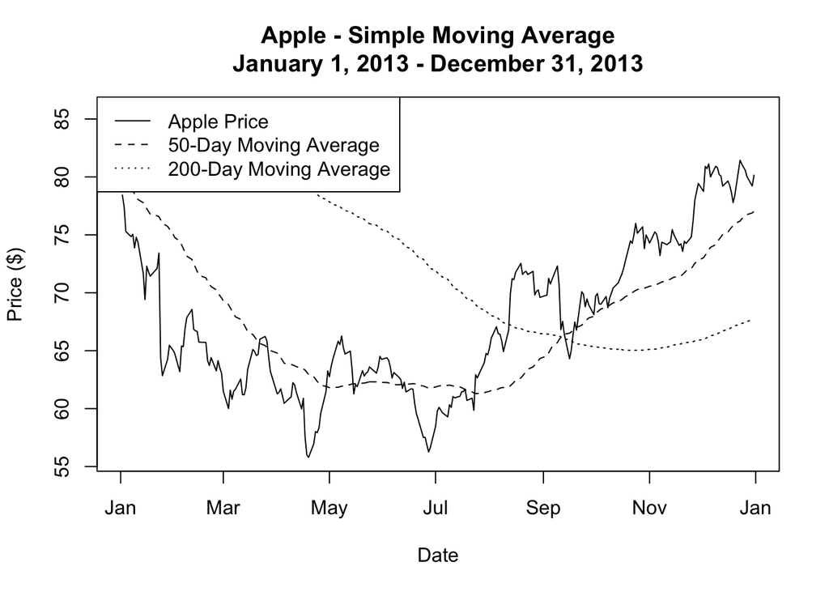

```r
# I subset the data again with longer term to show one year moving average
aapl.sma <- data.aapl[,"AAPL.Close"]
aapl.sma <- subset(aapl.sma, index(aapl.sma) >= "2012-01-01" & index(aapl.sma) <= "2013-12-31")
aapl.sma$sma50 <- rollmeanr(aapl.sma$AAPL.Close, k=50)
aapl.sma$sma200 <- rollmeanr(aapl.sma$AAPL.Close, k=200)
aapl.sma <- subset(aapl.sma, index(aapl.sma) >= "2013-01-01" & index(aapl.sma) <= "2013-12-31")
#Plot
y.range<-range(aapl.sma,na.rm=TRUE)
plot(x=index(aapl.sma), xlab="Date", y=aapl.sma$AAPL.Close, ylim=y.range,
ylab="Price ($)", type="l", main="Apple - Simple Moving Average
January 1, 2013 - December 31, 2013")
lines(x=index(aapl.sma),y=aapl.sma$sma50, lty=2)
lines(x=index(aapl.sma),y=aapl.sma$sma200,lty=3)
legend("topleft", c("Apple Price","50-Day Moving Average","200-Day Moving Average"),
lty=c(1,2,3))
```

- We can observe and compare the 50-Day Moving average and 200-Day Moving averaage to make decision. As you can see in the chart, 50-Day Moving Average cross over 200-Day Moving Average between September and October.
- This is called bullish crossover and when this happens, it can be taken as an indicator to buy the stock.

##### 3-2. Bollinger Band

[figure not shown]

```r
aapl.bb <- data.aapl[,"AAPL.Close"]
aapl.bb$avg<-rollmeanr(aapl.bb$AAPL.Close,k=20)
aapl.bb$sd<-rollapply(aapl.bb$AAPL.Close,width=20,FUN=sd,fill=NA)
aapl.bb2013<-subset(aapl.bb,index(aapl.sma) >= "2013-01-01" & index(aapl.sma) <= "2013-12-31")
aapl.bb2013$sd2up<-aapl.bb2013$avg+2*aapl.bb2013$sd
aapl.bb2013$sd2down<-aapl.bb2013$avg-2*aapl.bb2013$sd
#Plot
y.range<-range(aapl.bb2013[,-3],na.rm=TRUE)
plot(x=index(aapl.bb2013), xlab="Date", y=aapl.bb2013$AAPL.Close, ylim=y.range, ylab=
"Price ($)", type="l",
lwd=3, main="Apple - Bollinger Bands (20 days, 2 deviations)
January 1, 2013 - December 31, 2013")
lines(x=index(aapl.bb2013),y=aapl.bb2013$avg,lty=2)
lines(x=index(aapl.bb2013),y=aapl.bb2013$sd2up,col="gray40")
lines(x=index(aapl.bb2013),y=aapl.bb2013$sd2down,col="gray40")
legend("topleft", c("Apple Price","20-Day Moving Average","Upper Band","Lower Band")
,
lty=c(1,2,1,1), lwd=c(3,1,1,1), col=c("black","black","gray40","gray40"))
```

##### 3-3. RSI

```r
aapl.rsi <- data.aapl[,"AAPL.Close"]
aapl.rsi$delta<-diff(aapl.rsi$AAPL.Close)
aapl.rsi$up<-ifelse(aapl.rsi$delta>0,1,0)
aapl.rsi$down<-ifelse(aapl.rsi$delta<0,1,0)
aapl.rsi$up.val<-aapl.rsi$delta*aapl.rsi$up
aapl.rsi$down.val<--aapl.rsi$delta*aapl.rsi$down
aapl.rsi<-aapl.rsi[-1,]
aapl.rsi[c(1:3,nrow(aapl.rsi)),]
```

```
##            AAPL.Close     delta up down   up.val down.val
## 2012-01-04   59.06286  0.315716  1    0 0.315716 0.000000
## 2012-01-05   59.71857  0.655712  1    0 0.655712 0.000000
## 2012-01-06   60.34286  0.624286  1    0 0.624286 0.000000
## 2017-12-29  169.23000 -1.850006  0    1 0.000000 1.850006
```

```r
aapl.rsi$up.first.avg<-rollapply(aapl.rsi$up.val, width=14,FUN=mean,fill=NA,na.rm=TRUE)
aapl.rsi$down.first.avg<-rollapply(aapl.rsi$down.val, width=14,FUN=mean,fill=NA,na.rm
=TRUE)
up.val <- as.numeric(aapl.rsi$up.val)
down.val <- as.numeric(aapl.rsi$down.val)
aapl.rsi$up.avg <- aapl.rsi$up.first.avg
for (i in 15:nrow(aapl.rsi)){
aapl.rsi$up.avg[i] <-((aapl.rsi$up.avg[i-1]*13+up.val[i])/14)
}
aapl.rsi$down.avg <- aapl.rsi$down.first.avg
for (i in 15:nrow(aapl.rsi)){
aapl.rsi$down.avg[i]<- ((aapl.rsi$down.avg[i-1]*13+down.val[i])/14)
}
aapl.rsi$RS<-aapl.rsi$up.avg/aapl.rsi$down.avg
aapl.rsi$RSI<-100-(100/(1+aapl.rsi$RS))
aapl.rsi2013<-subset(aapl.rsi[,ncol(aapl.rsi)],index(aapl.rsi)>="2013-01-01"&index(aapl.rsi)<="2013-12-31")
aapl.rsi2013[c(1:3,nrow(aapl.rsi2013)),]
```

```
##                 RSI
## 2013-01-02 53.63051
## 2013-01-03 50.81948
## 2013-01-04 45.25357
## 2013-12-31 56.52015
```

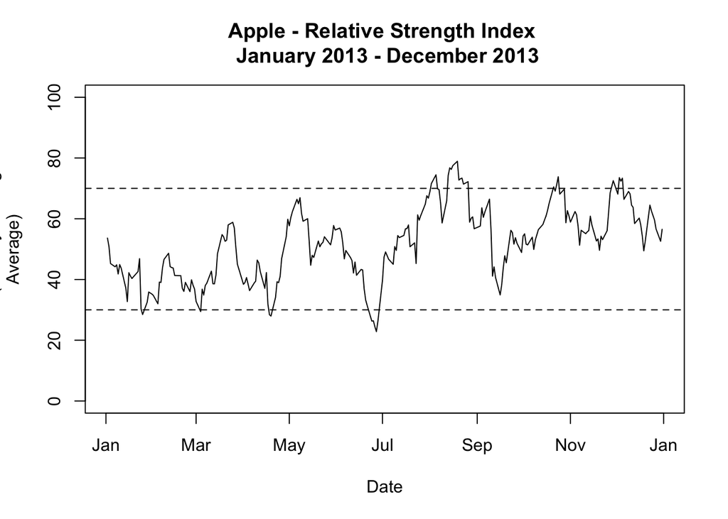

```r
title1<-"Apple - Relative Strength Index"
title2<-"January 2013 - December 2013"
plot(x=index(aapl.rsi2013), xlab="Date", y=aapl.rsi2013$RSI, ylab="RSI (14-Day Moving
Average)",
ylim=c(0,100), type="l", main=paste(title1,"\n",title2))
abline(h=c(30,70),lty=2)
```

- Around February, March, May, and July, we can see that RSI was below 30, which can be a signal that the stock was oversold.
- Also between August and September, and around Novemebr and December, we can see that RSI was above 70, which can be a signal that the stock was overbought.

### 4. Explain Exponential Moving Average with a plot (use data frame from question 1). – 4 Marks

```r
EMA50 <- EMA(Cl(data.aapl),n=50)
EMA200 <- EMA(Cl(data.aapl),n=200)
myIndicators_1 <- cbind.xts(Cl(data.aapl),EMA50,EMA200)
tail(myIndicators_1)
```

```
##            AAPL.Close      EMA    EMA.1
## 2017-12-21     175.01 168.8958 154.3664
## 2017-12-22     175.01 169.1356 154.5719
## 2017-12-26     170.57 169.1918 154.7310
## 2017-12-27     170.60 169.2470 154.8889
## 2017-12-28     171.08 169.3189 155.0500
## 2017-12-29     169.23 169.3154 155.1911
```

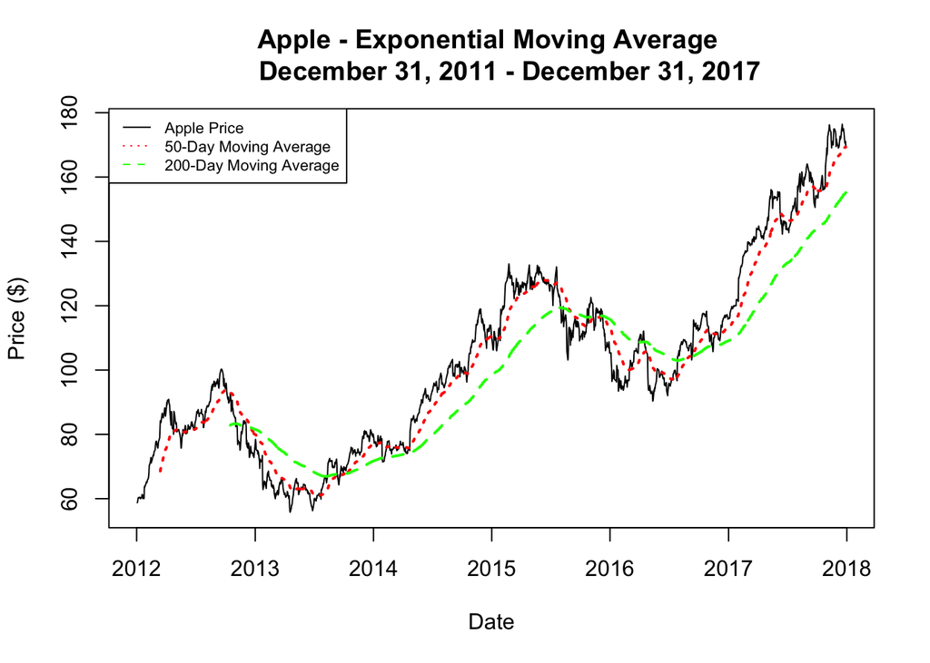

```r
y.range<-range(myIndicators_1,na.rm=TRUE)
plot(x=index(myIndicators_1), xlab="Date", y=myIndicators_1$AAPL.Close, ylim=y.range,
     ylab="Price ($)", type="l", main="Apple - Exponential Moving Average
     December 31, 2011 - December 31, 2017")
lines(x=index(myIndicators_1),y=myIndicators_1$EMA, lty=3, col=c("red"), lwd=2)
lines(x=index(myIndicators_1),y=myIndicators_1$EMA.1,lty=2, col= c("green"), lwd=2)
legend("topleft", c("Apple Price","50-Day Moving Average","200-Day Moving Average"),lty=c(1,3,2),col=c("black","red", "green"), cex=0.7)
```

### 5. Calculate Price, total and Logarithmic return using data frame from question 1. Plot Price return vs Total return. Explain the advantages of total return in 2-4 sentences. – 5 Marks

```r
# Price Return
aapl.price.ret <- data.aapl[,"AAPL.Close"]
aapl.price.ret$aapl.price.ret<-Delt(aapl.price.ret$AAPL.Close)
aapl.price.ret <- aapl.price.ret[,2]
aapl.price.ret[c(1:3,nrow(aapl.price.ret)),]
```

```
##            aapl.price.ret
## 2012-01-03             NA
## 2012-01-04    0.005374151
## 2012-01-05    0.011101935
## 2017-12-29   -0.010813689
```

```r
# Total Return
aapl.tot.ret <- data.aapl[,"AAPL.Adjusted"]
aapl.tot.ret$aapl.tot.ret=Delt(aapl.tot.ret$AAPL.Adjusted)
aapl.tot.ret <- aapl.tot.ret[,2]
aapl.tot.ret[c(1:3,nrow(aapl.tot.ret)),]
```

```
##            aapl.tot.ret
## 2012-01-03           NA
## 2012-01-04  0.005374129
## 2012-01-05  0.011102059
## 2017-12-29 -0.010813737
```

```r
# Logarithmic return
aapl.log.ret <- data.aapl[,"AAPL.Adjusted"]
aapl.log.ret$aapl.log.ret <- diff(log(aapl.log.ret$AAPL.Adjusted))
aapl.log.ret<-aapl.log.ret[,2]
aapl.log.ret[c(1:3,nrow(aapl.log.ret)),]
```

```
##            aapl.log.ret
## 2012-01-03           NA
## 2012-01-04   0.00535974
## 2012-01-05   0.01104088
## 2017-12-29  -0.01087263
```

```r
# Cumulative Logarithmic return
aapl.logcum <- aapl.log.ret
aapl.logcum[1,1]<-0
logcumret=sum(aapl.logcum$aapl.log.ret)
cumret=exp(logcumret)-1
cumret
```

```
## [1] 2.213458
```

```r
# Comparing Price return and Total return
aapl.Ret<-cbind(aapl.price.ret,aapl.tot.ret)
names(aapl.Ret)<-c("prc.ret","tot.ret")
aapl.Ret$prc.ret[1]<-0
aapl.Ret$tot.ret[1]<-0
aapl.Ret$gross.prc<-1+aapl.Ret$prc.ret
aapl.Ret$gross.tot<-1+aapl.Ret$tot.ret
aapl.Ret$cum.prc<-cumprod(aapl.Ret$gross.prc)
aapl.Ret$cum.tot<-cumprod(aapl.Ret$gross.tot)
aapl.Ret[nrow(aapl.Ret),c(5,6)] # Cumulative Price & Total return
```

```
##             cum.prc  cum.tot
## 2017-12-29 2.880651 3.213458
```

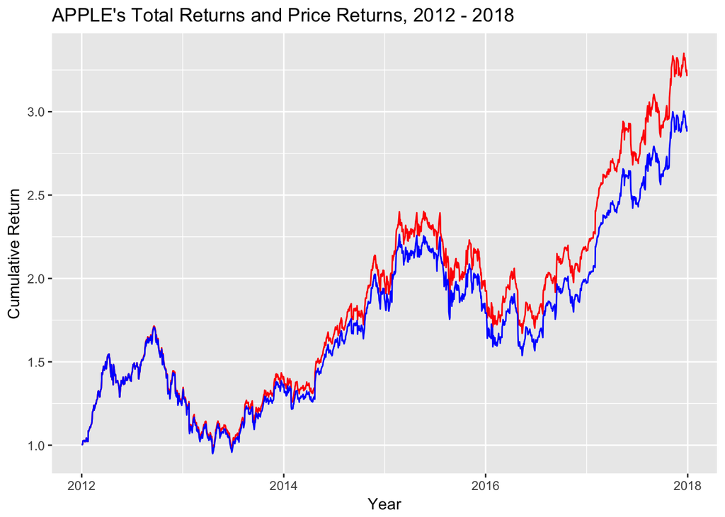

```r
ggplot(aapl.Ret) + geom_line(aes(x=index(aapl.Ret), y=cum.tot), col='red') + geom_line(aes(x=index(aapl.Ret), y=cum.prc), col='blue') + labs(x="Year", y="Cumulative Return", title="APPLE's Total Returns and Price Returns, 2012 - 2018")
```

- Cumulative Price Return: 2.880651
- Cumulative Total Return: 3.213458
- Cumulative Logarithmic Return: 2.213458
- Advantage of total return: total return enable us to properly make inferences from the data because it considers the adjustments to the closing price. The closing price of a stock is affected by stock splits or reverse stock splits and there are no adjustments to the closing price that reflects this. So, total return can complement this.

### 6. Compare the return: - 5 Marks

##### 6-1. Jan-2014 vs Jan-2015

```r
mo <-data.aapl
aapl.monthly <- to.monthly(mo)
aapl.monthly <- aapl.monthly[,6]
aapl.monthly$ret <- Delt(aapl.monthly$mo.Adjusted)
aapl.monthly$ret[index(aapl.monthly) == "Jan 2014"]
```

```
##                 ret
## Jan 2014 -0.1076968
```

```r
aapl.monthly$ret[index(aapl.monthly) == "Jan 2015"]
```

```
##                 ret
## Jan 2015 0.06142434
```

- Montly return of Jan-2014: -0.1076968
- Montly return of Jan-2015: 0.06142434

##### 6-2. Q2-2014 vs Q2-2015

```r
qu <- data.aapl
aapl.quarterly <- to.quarterly(qu)
aapl.quarterly <- aapl.quarterly[,6]
aapl.quarterly$ret <- Delt(aapl.quarterly$qu.Adjusted)
aapl.quarterly$ret[index(aapl.quarterly)=="2014 Q2"]
```

```
##               ret
## 2014 Q2 0.2187342
```

```r
aapl.quarterly$ret[index(aapl.quarterly)=="2015 Q2"]
```

```
##                ret
## 2015 Q2 0.01224742
```

- Quarterly return of Q2-2014: 0.2187342
- Quarterly return of Q2-2015: 0.01224742

### 7. Suppose you invested $100,000 in five stocks. Apple, Microsoft, Google, AT&T, Amazon ([.15, .25, .15, .25, 20]). Calculate the portfolio return from Jan-2011 to Dec-2017. Compare individual stock return with portfolio return using a plot. – 5 Marks

```r
data.aapl <- getSymbols("AAPL",from="2011-01-01",to="2017-12-31",auto.assign=FALSE)
data.msft <- getSymbols("MSFT",from="2011-01-01",to="2017-12-31",auto.assign=FALSE)
data.googl <- getSymbols("GOOGL",from="2011-01-01",to="2017-12-31",auto.assign=FALSE)
data.att <- getSymbols("T",from="2011-01-01",to="2017-12-31",auto.assign=FALSE)
data.amzn <- getSymbols("AMZN",from="2011-01-01",to="2017-12-31",auto.assign=FALSE)
return.aapl <- Return.calculate(data.aapl$AAPL.Adjusted)
return.msft <- Return.calculate(data.msft$MSFT.Adjusted)
return.googl <- Return.calculate(data.googl$GOOGL.Adjusted)
return.att <- Return.calculate(data.att$T.Adjusted)
return.amzn <- Return.calculate(data.amzn$AMZN.Adjusted)

multi <-cbind(return.aapl, return.msft, return.googl, return.att,return.amzn)
multi <- multi[-1,]
return.port <- Return.portfolio(multi, weights = c(.15, .25, .15, .25, .20))
cum.port <- Return.cumulative(return.port)
cum.aapl <- Return.cumulative(return.aapl)
cum.msft <- Return.cumulative(return.msft)
cum.googl <- Return.cumulative(return.googl)
cum.att <- Return.cumulative(return.att)
cum.amzn <- Return.cumulative(return.amzn)

cum.multi <- cbind(cum.port, cum.aapl, cum.msft, cum.googl, cum.att, cum.amzn)
cum.multi # cumulative return
```

```
##                   portfolio.returns AAPL.Adjusted MSFT.Adjusted
## Cumulative Return          2.787838      3.009681      2.685626
##                   GOOGL.Adjusted T.Adjusted AMZN.Adjusted
## Cumulative Return       2.482573  0.8917919      5.348225
```

```r
cum.multi * 100000
```

```
##                   portfolio.returns AAPL.Adjusted MSFT.Adjusted
## Cumulative Return          278783.8      300968.1      268562.6
##                   GOOGL.Adjusted T.Adjusted AMZN.Adjusted
## Cumulative Return       248257.3   89179.19      534822.5
```

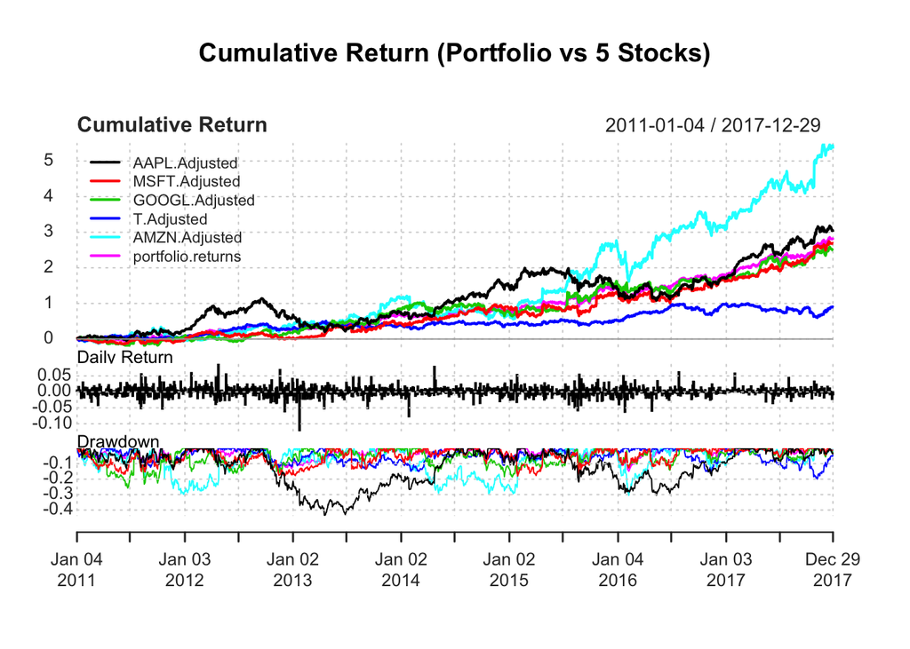

```r
multi.w.port <- cbind(multi,return.port)
charts.PerformanceSummary(multi.w.port, geometric=TRUE, main="Cumulative Return (Portfolio vs 5 Stocks)")
```

- Amazon cumulative return is the higest at 5.34.
- AT&T cumulative return is the lowest at 0.89.
- Portfolio return is 2.78.
- If we invested $100,000 in the beginning, it would become $278,783 with portfolio return, $300,968 with Apple return, $268,562 with Microsoft return, $248,257 with Google return, $89,179 with AT&T return, and $534822 with Amazon return.
- Even if portfolio return is not the highest, if we consider risk adjusted return, it would be the best investment.

### 8. Calculate two benchmark portfolio – a) Equal- weighted and b) Value-Weighted and calculate their return with yearly rebalancing. Compare your portfolio return with both the benchmarks return using a plot. Explain your result in 2-4 sentences. – 10 Marks

```r
# equal weighted
ew.port <- Return.portfolio(multi,  weights = c(.2, .2, .2, .2, .2), rebalance_on="years")
# value weighted
vwport <- cbind(data.aapl[,4],data.msft[,4],data.googl[,4],data.att[,4], data.amzn[,4], return.aapl,return.msft,return.googl,return.att,return.amzn )
vwport <- vwport[-1,]
colnames(vwport)[6:10] <- c("AAPL.ret","MSFT.ret","GOOGL.ret","T.ret","AMZN.ret")

price.yr <- vwport[,1:5]
price.yrs <- subset(price.yr, index(price.yr)=="2011-01-04" | index(price.yr)=="2012-01-04" | index(price.yr)=="2013-01-04" | index(price.yr)=="2014-01-03" | index(price.yr)=="2015-01-02" | index(price.yr)=="2016-01-04" | index(price.yr)=="2017-01-04")

price.yrs$aapl.shout<-c(6523000000,6591000000,6631000000,6310000000,5882000000 ,5594000000,5328000000)
price.yrs$msft.shout<-c( 8570000000, 8465000000, 8444000000, 8395000000, 8297000000, 8051000000,7830000000)
price.yrs$googl.shout<-c( 647000000, 654000000, 665000000, 737000000, 742000000, 745000000,748000000)
price.yrs$att.shout<-c(  5938000000 ,5950000000 ,5821000000 ,5385000000 ,5221000000 ,5646000000 ,6189000000)
price.yrs$amz.shout<-c( 456000000, 461000000, 453000000, 465000000, 462000000, 477000000,484000000)

weights <- price.yrs
weights$aapl.cap <- weights$AAPL.Close*weights$aapl.shout
weights$msft.cap <- weights$MSFT.Close*weights$msft.shout
weights$googl.cap <- weights$GOOGL.Close*weights$googl.shout
weights$att.cap <- weights$T.Close*weights$att.shout
weights$amzn.cap <- weights$AMZN.Close*weights$amz.shout
weights$tot.mcap <- rowSums(weights[,11:15])

weights$aapl.wgt <- weights$aapl.cap/weights$tot.mcap
weights$msft.wgt <- weights$msft.cap/weights$tot.mcap
weights$googl.wgt <- weights$googl.cap/weights$tot.mcap
weights$att.wgt <- weights$att.cap/weights$tot.mcap
weights$amzn.wgt <- weights$amzn.cap/weights$tot.mcap
weights <- weights[,17:21]
print("weights")
```

```
## [1] "weights"
```

```r
weights
```

```
##             aapl.wgt  msft.wgt googl.wgt    att.wgt   amzn.wgt
## 2011-01-04 0.3068069 0.2392434 0.1937757 0.17633082 0.08384313
## 2012-01-04 0.3529758 0.2103084 0.1983444 0.16417161 0.07419982
## 2013-01-04 0.3860637 0.1746132 0.1899469 0.15859066 0.09078556
## 2014-01-03 0.3092575 0.1965045 0.2584889 0.11884273 0.11690635
## 2015-01-02 0.3688767 0.2225422 0.2253864 0.10143450 0.08176023
## 2016-01-04 0.2814244 0.2106857 0.2701808 0.09261307 0.14509608
## 2017-01-04 0.2640158 0.2083448 0.2580609 0.11305574 0.15652272
```

```r
vw.port <- Return.portfolio(multi,  weights = weights)
portfolio <- cbind(ew.port[-1,], vw.port)
names(portfolio) <- c("EqualWeight", "ValueWeight")
portfolio[1,] <- c(0,0)
portfolio$ew.gross <- portfolio$EqualWeight + 1
portfolio$vw.gross <- portfolio$ValueWeight + 1
portfolio$ew.cum <- cumprod(portfolio$ew.gross)
portfolio$vw.cum <- cumprod(portfolio$vw.gross)

# cumulative returns
ew.Cumulative <-  Return.cumulative(ew.port)
vw.Cumulative <- Return.cumulative(vw.port)
print(paste("Equal Weighted Portfolio: ", ew.Cumulative))
```

```
## [1] "Equal Weighted Portfolio:  3.02918657320173"
```

```r
print(paste("Value Weighted Portfolio: ", vw.Cumulative))
```

```
## [1] "Value Weighted Portfolio:  2.68196777324664"
```

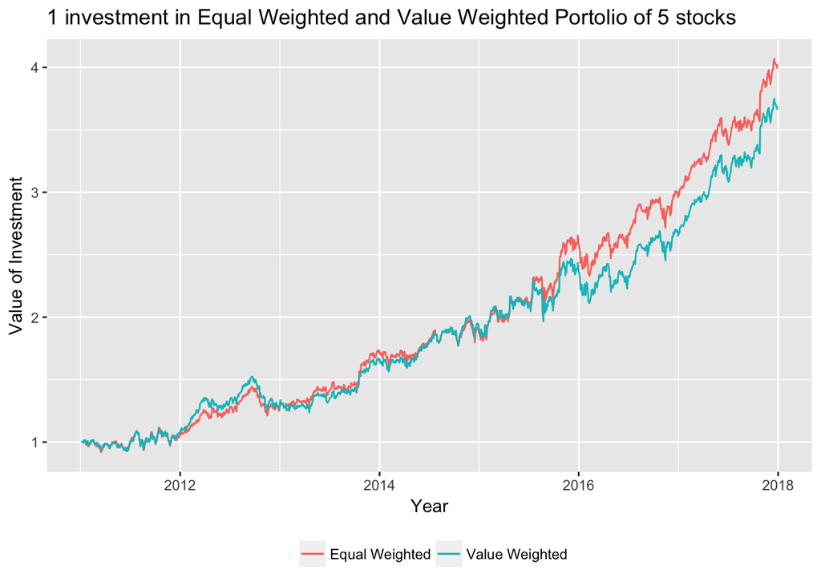

```r
# chart
ggplot(portfolio) + geom_line(aes(x=index(portfolio), y=ew.cum, col="Equal Weighted")) + geom_line(aes(x=index(portfolio), y=vw.cum, col="Value Weighted")) + labs(x="Year", y="Value of Investment", title="1 investment in Equal Weighted and Value Weighted Portolio of 5 stocks") + theme(legend.title = element_blank(), legend.position = "bottom")
```

- Figure above shows the performance of an investment in an EW and VW portfolio of APPLE, Microsoft, GOOGLE, AT&T, and AMAZON from January 01, 2011 to December 31, 2017.
- The cumulative equal weighted portfolio return is 3.0291
- The cumulative value weighted portfolio return is 2.6819
- The biggest reason why EW could have higher portfolio cumulative return is that EW invested 20% of fund on Amazon which has the highest cumulative return of 5.34 (see answer to question 7), but VW invested around only 8% to 15% on Amazon, which reduce the positive effect on portfolio.

### 9. Create a portfolio of Oracle, AT&T, Google, Texas Instruments, Intuitive Surgical and Visa over the time period - Jan-2011 to Dec-2017, equally-weighted and rebalanced monthly.

##### 9-a. Calculate Portfolio return. (Both Daily and Cumulative) - 2.5 Marks

```r
data.orcl <- getSymbols("ORCL",from="2011-01-01",to="2017-12-31",auto.assign=FALSE)
data.att <- getSymbols("T",from="2011-01-01",to="2017-12-31",auto.assign=FALSE)
data.googl <- getSymbols("GOOGL",from="2011-01-01",to="2017-12-31",auto.assign=FALSE)
data.txn <- getSymbols("TXN",from="2011-01-01",to="2017-12-31",auto.assign=FALSE)
data.isrg <- getSymbols("ISRG",from="2011-01-01",to="2017-12-31",auto.assign=FALSE)
data.visa <- getSymbols("V",from="2011-01-01",to="2017-12-31",auto.assign=FALSE)

return.orcl <- Return.calculate(data.orcl$ORCL.Adjusted)
return.att <- Return.calculate(data.att$T.Adjusted)
return.googl <- Return.calculate(data.googl$GOOGL.Adjusted)
return.txn <- Return.calculate(data.txn$TXN.Adjusted)
return.isrg <- Return.calculate(data.isrg$ISRG.Adjusted)
return.visa <- Return.calculate(data.visa$V.Adjusted)

multi <-cbind(return.orcl, return.att, return.googl, return.txn,return.isrg ,return.visa)
multi <- multi[-1,]
return.port <- Return.portfolio(multi, weights = rep(1/6, 6), rebalance_on = "months")
#daily return
return.port[c(1:3, nrow(return.port)),]
```

```
##            portfolio.returns
## 2011-01-04       0.001383116
## 2011-01-05       0.005530919
## 2011-01-06       0.001394596
## 2017-12-29      -0.005306658
```

```r
#cumulative return
return.port$gross <- return.port$portfolio.returns+1
return.port$cum <- cumprod(return.port$gross)
return.port[c(1:3, nrow(return.port)),3]
```

```
##                 cum
## 2011-01-04 1.001383
## 2011-01-05 1.006922
## 2011-01-06 1.008326
## 2017-12-29 3.598872
```

##### 9-b. Calculate Risks Sharpe ratio associate with your portfolio - 2.5 Marks

```r
orcl.mo <- to.monthly(data.orcl)
att.mo <- to.monthly(data.att)
googl.mo <- to.monthly(data.googl)
txn.mo <- to.monthly(data.txn)
isrg.mo <- to.monthly(data.isrg)
visa.mo <- to.monthly(data.visa)

orcl.mo.ret <- Return.calculate(orcl.mo[,6])
att.mo.ret  <- Return.calculate(att.mo[,6])
googl.mo.ret  <- Return.calculate(googl.mo[,6])
txn.mo.ret  <- Return.calculate(txn.mo[,6])
isrg.mo.ret  <-  Return.calculate(isrg.mo[,6])
visa.mo.ret  <-  Return.calculate(visa.mo[,6])

multi.mo <-cbind(orcl.mo.ret, att.mo.ret, googl.mo.ret, txn.mo.ret,isrg.mo.ret ,visa.mo.ret)
multi.mo <- multi.mo[-1,]
return.port.mo <- Return.portfolio(multi.mo, weights = rep(1/6, 6), rebalance_on = "months")

Rf = .0007
# minimum acceptable return
mar<-0.015
annual.port.ret<-mean(return.port.mo$portfolio.returns)*12
annual.port.ret
```

```
## [1] 0.1883454
```

```r
annual.port.sd<-sd(return.port.mo$portfolio.returns)*sqrt(12)
annual.port.sd
```

```
## [1] 0.1125143
```

```r
Sharpe.port<-(annual.port.ret - Rf)/annual.port.sd
print(paste("Sharpe Ratio: ", Sharpe.port))
```

```
## [1] "Sharpe Ratio:  1.66774674095783"
```

- Sharpe Ratio: 1.6677

##### 9-c. Calculate historical VaR - 2.5 Marks

```r
return.orcl <- Return.calculate(data.orcl$ORCL.Adjusted)
return.att <- Return.calculate(data.att$T.Adjusted)
return.googl <- Return.calculate(data.googl$GOOGL.Adjusted)
return.txn <- Return.calculate(data.txn$TXN.Adjusted)
return.isrg <- Return.calculate(data.isrg$ISRG.Adjusted)
return.visa <- Return.calculate(data.visa$V.Adjusted)

multi <-cbind(return.orcl, return.att, return.googl, return.txn,return.isrg ,return.visa)
multi <- multi[-1,]

ret.cum.orcl <- Return.cumulative(return.orcl)
ret.cum.att <- Return.cumulative(return.att)
ret.cum.googl <- Return.cumulative(return.googl)
ret.cum.txn <- Return.cumulative(return.txn)
ret.cum.isrg <- Return.cumulative(return.isrg)
ret.cum.visa <- Return.cumulative(return.visa)
equal.amt <- 1000000*1/6

orcl.val <- as.numeric(equal.amt*(1+ret.cum.orcl))
att.val <- as.numeric(equal.amt*(1+ret.cum.att))
googl.val <- as.numeric(equal.amt*(1+ret.cum.googl))
txn.val <- as.numeric(equal.amt*(1+ret.cum.txn))
isrg.val <- as.numeric(equal.amt*(1+ret.cum.isrg))
visa.val <- as.numeric(equal.amt*(1+ret.cum.visa))

tot.val <- sum(orcl.val,att.val,googl.val,txn.val,isrg.val,visa.val)
tot.val
```

```
## [1] 3740284
```

```r
sim.portPnL <- orcl.val*multi$ORCL.Adjusted + att.val*multi$T.Adjusted + googl.val*multi$GOOGL.Adjusted + txn.val*multi$TXN.Adjusted + isrg.val*multi$ISRG.Adjusted + visa.val*multi$V.Adjusted

names(sim.portPnL) <- "Port.PnL"
head(sim.portPnL)
```

```
##              Port.PnL
## 2011-01-04   5952.919
## 2011-01-05  37845.797
## 2011-01-06  16400.012
## 2011-01-07  -9097.814
## 2011-01-10 -13725.008
## 2011-01-11  23501.055
```

```r
#Historical VaR at 1% and 5%
VaR01.Historical=quantile(-sim.portPnL$Port.PnL,0.99)
VaR01.Historical
```

```
##      99%
## 100287.8
```

```r
VaR05.Historical=quantile(-sim.portPnL$Port.PnL,0.95)
VaR05.Historical
```

```
##      95%
## 63680.79
```

- If I invested $1,000,000 on this portfolio, I’m 95% confident that my daily loss will not exceed $63,680.
- If I invested $1,000,000 on this portfolio, I’m 99% confident that my daily loss will not exceed $100,287

##### 9-d. Calculated historical Expected Shortfall - 2.5 Marks

```r
ES.PnL <-sim.portPnL$Port.PnL
ES.PnL$dummy01<-ifelse(ES.PnL$Port.PnL< (- VaR01.Historical) ,1,0)
ES.PnL$dummy05<-ifelse(ES.PnL$Port.PnL< (-VaR05.Historical) ,1,0)
head(ES.PnL)
```

```
##              Port.PnL dummy01 dummy05
## 2011-01-04   5952.919       0       0
## 2011-01-05  37845.797       0       0
## 2011-01-06  16400.012       0       0
## 2011-01-07  -9097.814       0       0
## 2011-01-10 -13725.008       0       0
## 2011-01-11  23501.055       0       0
```

```r
shortfall01<-subset(ES.PnL,ES.PnL$dummy01==1)
shortfall05<-subset(ES.PnL,ES.PnL$dummy05==1)
ES01.Historical<- -mean(shortfall01$Port.PnL)
ES01.Historical
```

```
## [1] 127688.6
```

```r
ES05.Historical<- -mean(shortfall05$Port.PnL)
ES05.Historical
```

```
## [1] 88212.63
```

- We have a 5% probability that the loss in our portfolio would exceed the VaR, but when it does, we expect that, on average, we woud lose $88,212.
- We have a 1% probability that the loss in our portfolio would exceed the VaR, but when it does, we expect that, on average, we woud lose $127,688.